# Reproducibility Report: Group B Choice 3

For this exercise, please try to reproduce the results from Experiment 2 of the associated paper (de la Fuente, Santiago, Roman, Dumitrache, & Casasanto, 2014). The PDF of the paper is included in the same folder as this Rmd file.

#### Methods summary:

Researchers tested the question of whether temporal focus differs between Moroccan and Spanish cultures, hypothesizing that Moroccans are more past-focused, whereas Spaniards are more future-focused. Two groups of participants ($N = 40$ Moroccan and $N=40$ Spanish) completed a temporal-focus questionnaire that contained questions about past-focused (“PAST”) and future-focused (“FUTURE”) topics. In response to each question, participants provided a rating on a 5-point Likert scale on which lower scores indicated less agreement and higher scores indicated greater agreement. The authors then performed a mixed-design ANOVA with agreement score as the dependent variable, group (Moroccan or Spanish, between-subjects) as the fixed-effects factor, and temporal focus (past or future, within-subjects) as the random effects factor. In addition, the authors performed unpaired two-sample t-tests to determine whether there was a significant difference between the two groups in agreement scores for PAST questions, and whether there was a significant difference in scores for FUTURE questions.

#### Target outcomes:

Below is the specific result you will attempt to reproduce (quoted directly from the results section of Experiment 2):

> According to a mixed analysis of variance (ANOVA) with group (Spanish vs. Moroccan) as a between-subjects factor and temporal focus (past vs. future) as a within-subjectS factor, temporal focus differed significantly between Spaniards and Moroccans, as indicated by a significant interaction of temporal focus and group, F(1, 78) = 19.12, p = .001, ηp2 = .20 (Fig. 2). Moroccans showed greater agreement with past-focused statements than Spaniards did, t(78) = 4.04, p = .001, and Spaniards showed greater agreement with future-focused statements than Moroccans did, t(78) = −3.32, p = .001. (de la Fuente et al., 2014, p. 1685).

# Step 1: Load packages

```r
library(tidyverse) # for data munging
library(knitr) # for kable table formating
library(haven) # import and export 'SPSS', 'Stata' and 'SAS' Files
library(readxl) # import excel files
library(ggplot2)

# #optional packages/functions:
library(afex) # anova functions
# library(ez) # anova functions 2
# library(scales) # for plotting
# std.err <- function(x) sd(x)/sqrt(length(x)) # standard error
```

# Step 2: Load data

```r
# Just Experiment 2
data_path <- 'data/DeLaFuenteEtAl_2014_RawData.xls'
d <- read_excel(data_path, sheet=3)
print(head(d))
```

```
## # A tibble: 6 × 5
##   group    participant subscale item                      Agreement (0=complet…¹
##   <chr>          <dbl> <chr>    <chr>                                      <dbl>
## 1 Moroccan           1 PAST     1. Para mí son muy impor…                      4
## 2 Moroccan           1 PAST     2. Los jóvenes deben con…                      4
## 3 Moroccan           1 PAST     3. Creo que las personas…                      5
## 4 Moroccan           1 PAST     4. La juventud de hoy en…                      2
## 5 Moroccan           1 PAST     5. Los ancianos saben má…                      4
## 6 Moroccan           1 PAST     6. El modo correcto de h…                      3
## # ℹ abbreviated name:
## #   ¹`Agreement (0=complete disagreement; 5=complete agreement)`
```

# Step 3: Tidy data

Note: The scale for Agreement is (0=complete disagreement; 5=complete agreement)

```r
tidy_df <- d %>%
  rename(Agreement = `Agreement (0=complete disagreement; 5=complete agreement)`)
print(head(tidy_df))
```

```
## # A tibble: 6 × 5
##   group    participant subscale item                                   Agreement
##   <chr>          <dbl> <chr>    <chr>                                      <dbl>
## 1 Moroccan           1 PAST     1. Para mí son muy importantes las tr…         4
## 2 Moroccan           1 PAST     2. Los jóvenes deben conservar las tr…         4
## 3 Moroccan           1 PAST     3. Creo que las personas eran más fel…         5
## 4 Moroccan           1 PAST     4. La juventud de hoy en día necesita…         2
## 5 Moroccan           1 PAST     5. Los ancianos saben más que los jóv…         4
## 6 Moroccan           1 PAST     6. El modo correcto de hacer las cosa…         3
```

# Step 4: Run analysis

## Pre-processing

```r
tidy_df <- tidy_df %>%
  mutate(group = ifelse(group == "young Spaniard", "Spaniard", group))
```

## Descriptive statistics

Try to recreate Figure 2 (fig2.png, also included in the same folder as this Rmd file):

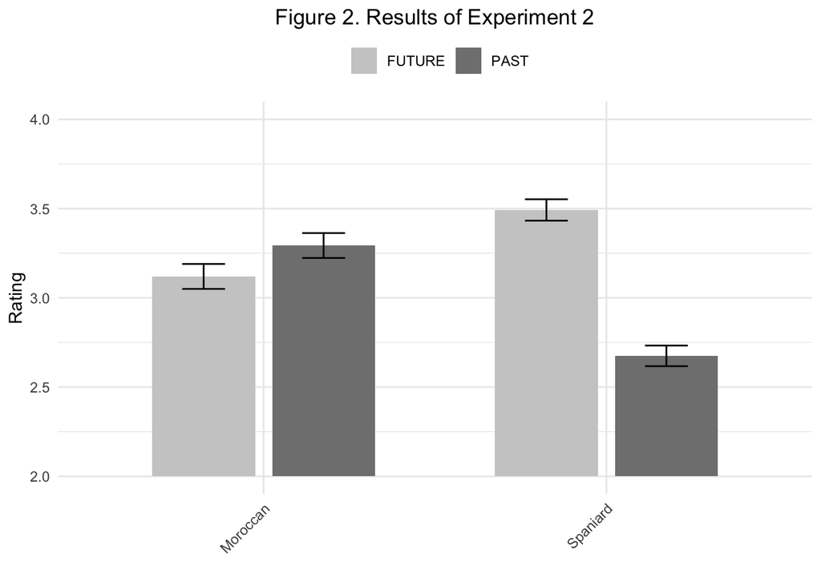

```r
# Calculate mean and standard error
summary_df <- tidy_df %>%
  group_by(group, subscale) %>%
  summarise(
    mean = mean(Agreement, na.rm = TRUE),
    sd = sd(Agreement, na.rm = TRUE),
    se = sd / sqrt(n())
  ) %>%
  ungroup()

# Create the plot
ggplot(summary_df, aes(x = group, y = mean, fill = subscale)) +
  geom_bar(stat = "identity", position = position_dodge(width = 0.7), width = 0.6) +
  geom_errorbar(aes(ymin = mean - se, ymax = mean + se),
                position = position_dodge(width = 0.7), width = 0.25) +
  scale_y_continuous(limits = c(2, 4), oob = scales::squish) + # Setting the y-axis limits
  labs(x = "", y = "Rating") +
  scale_fill_grey(start = 0.8, end = 0.5) +
  theme_minimal() +
  theme(legend.title = element_blank(),
        legend.position = "top",
        axis.text.x = element_text(angle = 45, hjust = 1),
        plot.title = element_text(hjust = 0.5)) +
  ggtitle("Figure 2. Results of Experiment 2")
```

## Inferential statistics

> According to a mixed analysis of variance (ANOVA) with group (Spanish vs. Moroccan) as a between-subjects factor and temporal focus (past vs. future) as a within-subjects factor, temporal focus differed significantly between Spaniards and Moroccans, as indicated by a significant interaction of temporal focus and group, F(1, 78) = 19.12, p = .001, ηp2 = .20 (Fig. 2).

```r
tidy_df$unique_id <- interaction(tidy_df$group, tidy_df$participant)

# Run a mixed ANOVA
anova_results <- aov_ez("unique_id", "Agreement", tidy_df, between = "group", within = "subscale", detailed = TRUE)

# Get the summary of the ANOVA
summary_table <- summary(anova_results)

# Extract the F value, degrees of freedom, and p-value for the interaction effect
interaction_effect <- anova_results$anova_table[3,]

result_string <- sprintf("F(%d, %d) = %.2f, p = %.5f, ηp² = %.2f", interaction_effect$`num Df`, interaction_effect$`den Df`, interaction_effect$F, interaction_effect$`Pr(>F)`, interaction_effect$ges)
print(result_string)
```

```
## [1] "F(1, 76) = 18.35, p = 0.00005, ηp² = 0.15"
```

> Moroccans showed greater agreement with past-focused statements than Spaniards did, t(78) = 4.04, p = .001,

```r
mean_agreement <- tidy_df %>%
  group_by(group, subscale, unique_id) %>%
  summarize(mean_agreement = mean(Agreement, na.rm = TRUE), .groups = 'drop')

t_test_results <- t.test(mean_agreement ~ group, data = subset(mean_agreement, subscale == "PAST"))

# Output the results
print(t_test_results)
```

```
##
##  Welch Two Sample t-test
##
## data:  mean_agreement by group
## t = 3.8562, df = 74.91, p-value = 0.0002416
## alternative hypothesis: true difference in means between group Moroccan and group Spaniard is not equal to 0
## 95 percent confidence interval:
##  0.2850812 0.8944060
## sample estimates:
## mean in group Moroccan mean in group Spaniard
##               3.280886               2.691142
```

> and Spaniards showed greater agreement with future-focused statements than Moroccans did, t(78) = −3.32, p = .001.(de la Fuente et al., 2014, p. 1685)

```r
t_test_results <- t.test(mean_agreement ~ group, data = subset(mean_agreement, subscale == "FUTURE"))

# Output the results
print(t_test_results)
```

```
##
##  Welch Two Sample t-test
##
## data:  mean_agreement by group
## t = -3.2098, df = 70.047, p-value = 0.002005
## alternative hypothesis: true difference in means between group Moroccan and group Spaniard is not equal to 0
## 95 percent confidence interval:
##  -0.5762537 -0.1345797
## sample estimates:
## mean in group Moroccan mean in group Spaniard
##               3.138333               3.493750
```

# Step 5: Reflection

Were you able to reproduce the results you attempted to reproduce? If not, what part(s) were you unable to reproduce?

I was able to reproduce the general direction of the results, but not the exact numbers. I think there may have been some issues with excluding the data that were different for their work and mine.

How difficult was it to reproduce your results?

It wasn’t too difficult, however more instructions for the F test and knowing to take the mean for the t test would have been helpful.

What aspects made it difficult? What aspects made it easy?

The difficult part was largely not being sure what preprocessing I would be doing. ChatGPT made going through this much easier though, as I was able to get code for what I wanted to do.